# EDA final Project Zhaoyuan Cai

Four principles of EDA (the four R’s)}

Revelation:In EDA, there is an emphasis on using graphs to find patterns or displayingfits. Effective displays of data can communicate information in way that is not possibleby the use of numbers. A good rule of thumb is to always graph your data before commuting any summary statistic. There will be a lot of graphing in this course, andwe’ll discuss guidelines for constructing effective graphs.

Resistance:In EDA, we wish to describe the general pattern in the majority of thedata. In this detective work, we don’t want our search to be unusually affected by afew unusual observations. So it is important that our exploratory method is resistantor insensitive to outliers. When we look at a single batch of numbers, we’ll see that themedian or middle value (when the data are arranged in ascending order) is an exampleof a resistant measure. The mean or arithmetic average is nonresistant since it can bedistorted by one or more extreme values.

Reexpression:We will see that the natural scale that the data is presented is notalways the best scale for displaying or summarizing the data. In many situations, wewish to reexpress the data to a new scale by taking a square root or a logarithm. In thisclass, we will talk about a useful class of reexpressions, called the power family, andgive guidance on the “best” choice of power reexpression to simplify the data analysis.

Residual:In a typical data analysis, we will find a general pattern, which we call the FIT. The description of the FIT may be very informative. But in EDA we wish to lookfor deviations in the data from the general pattern in the FIT. We look at the residuals,which are defined as the difference between the data and the FIT.

The data set I chose is related to various indicators of red wine, including sugar content, PH, citric acid, alcohol and other indicators.

The purpose of this project is to explore the relationship between citric.acid and pH in red wine. The method I choose is Straightening.

```r
# Meet Data
library(LearnEDAfunctions)
wineQualityReds <- read.csv("~/Desktop/R-Project-master/红酒数据分析/wineQualityReds.csv")
View(wineQualityReds)
```

```r
wineQualityReds <- wineQualityReds[,-1]
View(wineQualityReds)
```

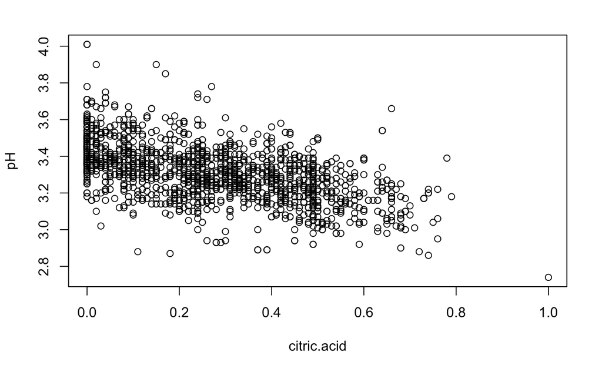

```r
#A nonlinear relationship
with(wineQualityReds,
     plot(citric.acid, pH))
```

As expected, we see a pretty strong negative relationship. But what is evident is that this isnot a straight-line relationship.

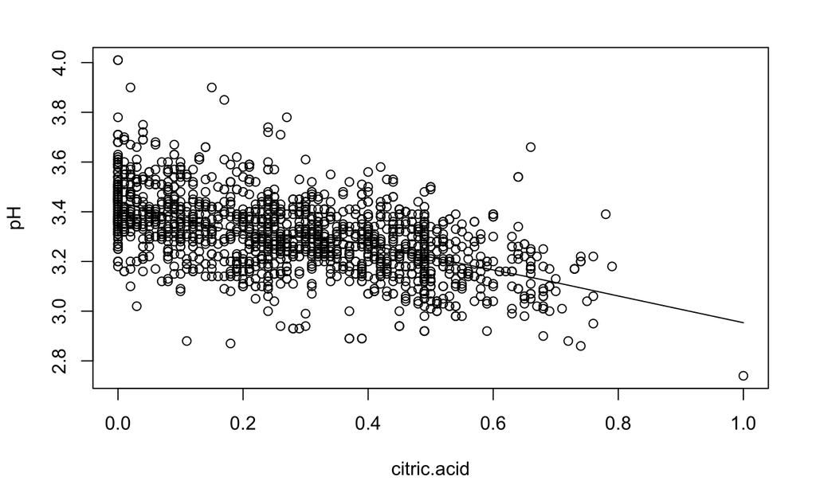

```r
with(wineQualityReds,
     plot(citric.acid, pH))
with(wineQualityReds,
    lines(lowess(citric.acid, pH, f=0.5)))
```

Recall that our method of fitting a line, the resistant line, is based on working with threesummary points. Likewise, we use three summary points to measure the curvature in theplot and help us choose an appropriate reexpression to straighten.As before, we find three summary points by breaking thex-values (herexis displacement)into three groups of approximate equal size (low, middle, and high), and finding the medianx-value and the mediany-value in each group.

```r
data <- data.frame(wineQualityReds$citric.acid, wineQualityReds$pH)
sorted.data <- data[order(wineQualityReds$citric.acid),]
round(sorted.data,2)
```

|  | wineQualityReds.citric.acid | wineQualityReds.pH |
| --- | --- | --- |
| 1 | 0.00 | 3.51 |
| 2 | 0.00 | 3.20 |
| 5 | 0.00 | 3.51 |
| 6 | 0.00 | 3.51 |
| 8 | 0.00 | 3.39 |
| 13 | 0.00 | 3.58 |
| 29 | 0.00 | 3.47 |
| 30 | 0.00 | 3.38 |
| 32 | 0.00 | 3.46 |
| 36 | 0.00 | 3.40 |

[output cut: 990 more lines]

```r
median(sorted.data$wineQualityReds.citric.acid[1:533])
```

```
[1] 0.04
```

```r
median(sorted.data$wineQualityReds.citric.acid[534:1066])
```

```
[1] 0.26
```

```r
median(sorted.data$wineQualityReds.citric.acid[1067:1599])
```

```
[1] 0.49
```

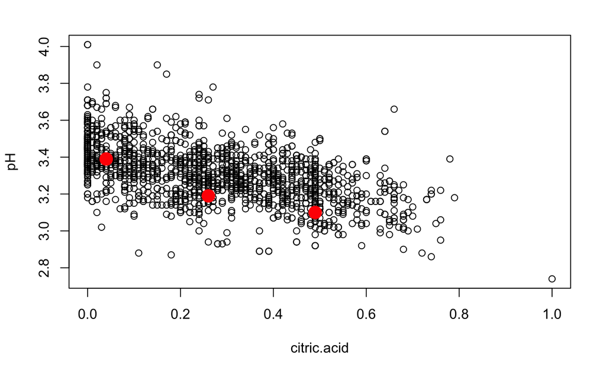

```r
#These points are plotted as red dots in the figure below.
with(wineQualityReds,
     plot(citric.acid, pH))
summary.points <- data.frame(x=c(0.04,0.26,0.49),
                             y=c(3.39,3.19,3.1))
points(summary.points, cex = 2, pch = 19, col = "red")
```

We can measure the curvature in this plot by first computing the “left slope” (the slope ofthe line connecting the left and middle summary points), the “right slope” (the slope of thesegment connecting the middle and right summary points). The ratio of the right slope tothe left slope, the so-called half-slope ratio, is a measure of the curvature of the plot. The figure below illustrates the computation of the half-slope ratio. The left slope of thesegment connecting the left two points is mL = (3.39-3.19)/(0.04-0.26) = -0.9 and the slope of the segment connecting the two right points is mR = (3.19-3.1)/(0.26-0.49)= -0.39 So the half-slope ratio, denoted bHS, is bHS = mR/mL= 0.43

```r
with(wineQualityReds,
     plot(citric.acid, pH))
points(summary.points, cex=2, pch=19, col="red")
```

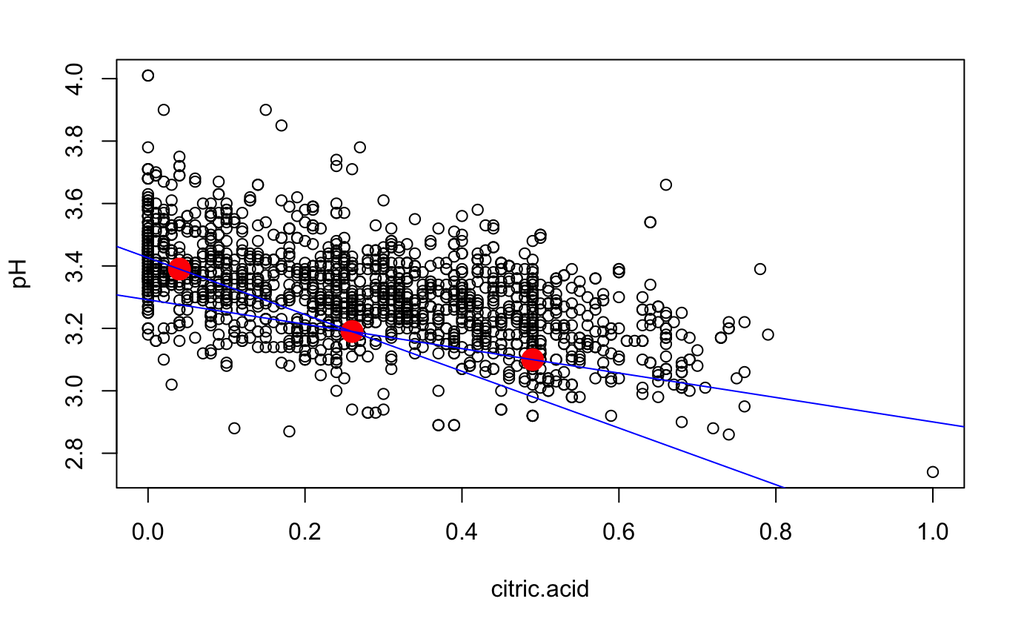

```r
abline(lm(y~x, data = summary.points[1:2,]), col="blue")
abline(lm(y~x, data = summary.points[2:3,]), col="blue")
```

Below we write a short functions traightening.work to illustrate the computations. We start with the original data – the following table shows the left, center, and right summary points, the transformed summary points (tx, ty), the left and right slopes and the half-slope ratio. This is old news – the ratio is 0.43 which indicates curvature in the plot.

```r
straightening.work <- function(sp, px, py){
  sp$tx <-with(sp, (x ^ px - 1) / px)
  sp$ty <-with(sp, (y ^ py - 1) / py)
  sp$slope[1] <-with(sp,diff(ty[1:2]) /diff(tx[1:2]))
  sp$slope[2] <-with(sp,diff(ty[2:3]) /diff(tx[2:3]))
  sp$half.slope.ratio <-with(sp, slope[2] / slope[1])
  sp$slope[3] <- NA
  sp$half.slope.ratio[2:3] <- NA
  row.names(sp) <-c("Left", "Center", "Right")
  sp}
straightening.work(summary.points, 1, 1)
```

|  | x | y | tx | ty | slope | half.slope.ratio |
| --- | --- | --- | --- | --- | --- | --- |
| Left | 0.04 | 3.39 | -0.96 | 2.39 | -0.9090909 | 0.4304348 |
| Center | 0.26 | 3.19 | -0.74 | 2.19 | -0.3913043 | NA |
| Right | 0.49 | 3.10 | -0.51 | 2.10 | NA | NA |

```r
straightening.work(summary.points, 0.5, 1)
```

|  | x | y | tx | ty | slope | half.slope.ratio |
| --- | --- | --- | --- | --- | --- | --- |
| Left | 0.04 | 3.39 | -1.6000000 | 2.39 | -0.3226827 | 0.7335997 |
| Center | 0.26 | 3.19 | -0.9801961 | 2.19 | -0.2367199 | NA |
| Right | 0.49 | 3.10 | -0.6000000 | 2.10 | NA | NA |

```r
straightening.work(summary.points, 0.5, 0.5)
```

|  | x | y | tx | ty | slope | half.slope.ratio |
| --- | --- | --- | --- | --- | --- | --- |
| Left | 0.04 | 3.39 | -1.6000000 | 1.682391 | -0.1779213 | 0.750253 |
| Center | 0.26 | 3.19 | -0.9801961 | 1.572114 | -0.1334860 | NA |
| Right | 0.49 | 3.10 | -0.6000000 | 1.521363 | NA | NA |

```r
straightening.work(summary.points, 0.001, 1)
```

|  | x | y | tx | ty | slope | half.slope.ratio |
| --- | --- | --- | --- | --- | --- | --- |
| Left | 0.04 | 3.39 | -3.2137008 | 2.39 | -0.1070931 | 1.327481 |
| Center | 0.26 | 3.19 | -1.3461668 | 2.19 | -0.1421641 | NA |
| Right | 0.49 | 3.10 | -0.7130955 | 2.10 | NA | NA |

```r
straightening.work(summary.points, 0.001, 0.001)
```

|  | x | y | tx | ty | slope | half.slope.ratio |
| --- | --- | --- | --- | --- | --- | --- |
| Left | 0.04 | 3.39 | -3.2137008 | 1.221575 | -0.03259991 | 1.38829 |
| Center | 0.26 | 3.19 | -1.3461668 | 1.160694 | -0.04525812 | NA |
| Right | 0.49 | 3.10 | -0.7130955 | 1.132042 | NA | NA |

```r
straightening.work(summary.points, 0.001, -1)
```

|  | x | y | tx | ty | slope | half.slope.ratio |
| --- | --- | --- | --- | --- | --- | --- |
| Left | 0.04 | 3.39 | -3.2137008 | 0.7050147 | -0.009903098 | 1.451665 |
| Center | 0.26 | 3.19 | -1.3461668 | 0.6865204 | -0.014375983 | NA |
| Right | 0.49 | 3.10 | -0.7130955 | 0.6774194 | NA | NA |

```r
straightening.work(summary.points, -0.33, -1)
```

|  | x | y | tx | ty | slope | half.slope.ratio |
| --- | --- | --- | --- | --- | --- | --- |
| Left | 0.04 | 3.39 | -5.7357938 | 0.7050147 | -0.004578336 | 2.228663 |
| Center | 0.26 | 3.19 | -1.6962535 | 0.6865204 | -0.010203566 | NA |
| Right | 0.49 | 3.10 | -0.8043083 | 0.6774194 | NA | NA |

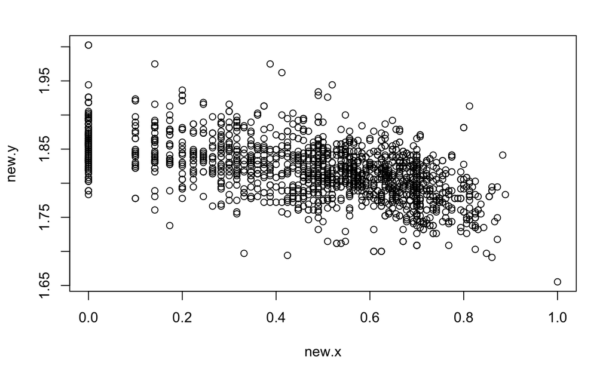

```r
# Making sense of the reexpression
# Straightening, fitting, and flattening
new.x <- wineQualityReds$citric.acid ^ (0.5)
new.y <- wineQualityReds$pH ^ (0.5)
plot(new.x, new.y)
```

This looks pretty straight. To detect any remaining curvature, we will fit a line and inspectthe residuals.

```r
data<-data.frame(new.x,new.y)
myfit<-rline(new.y~new.x,data,iter = 1)
myfit
```

```
$a
[1] 1.81252

$b
[1] -0.09909595

$xC
[1] 0.509902

$half.slope.ratio
[1] 1.652608

$residual
   [1]  1.044995e-02 -7.419507e-02 -3.768325e-02 -1.125394e-02  1.044995e-02  1.044995e-02
   [7] -2.218578e-02 -2.185418e-02 -1.600489e-02  2.670865e-02 -2.394385e-02  2.670865e-02
```

[output cut: 172 more lines]

```r
FIT <- with(myfit, a+b*(new.x-xC))
```

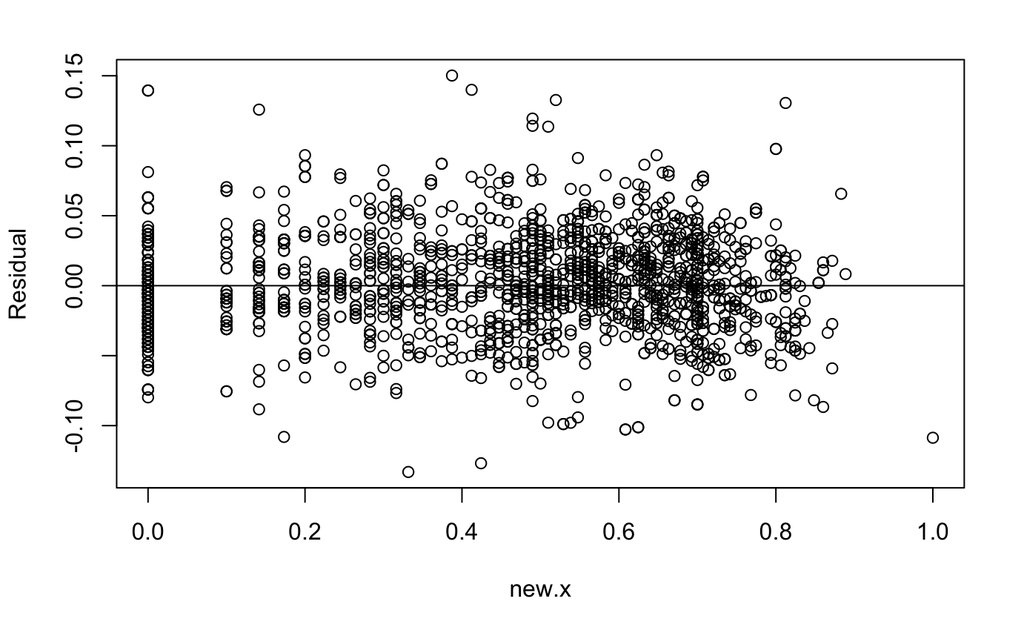

```r
plot(new.x, myfit$residual, ylab="Residual")
abline(h=0)
```